# Examen Practico M2-Seccion B

Lucía Pena Pais

24/03/2021

## Importación datos

```r
setwd("C:/Users/Usuario/Documents/Master BI/M2 - Herramientas Big Data/Evaluación M2")
suppressPackageStartupMessages(library(readr))
datos <- read_csv("listings.csv")
head(datos)
```

```
## # A tibble: 6 x 16
##      id name  host_id host_name neighbourhood_g~ neighbourhood latitude
##   <dbl> <chr>   <dbl> <chr>     <chr>            <chr>            <dbl>
## 1  6369 "Roo~   13660 Simon     Chamartín        Hispanoaméri~     40.5
## 2 21853 "Bri~   83531 Abdel     Latina           Cármenes          40.4
## 3 23001 "Apa~   82175 Jesus     Arganzuela       Legazpi           40.4
## 4 24805 "Gra~  101471 Iraido    Centro           Universidad       40.4
## 5 24836 "Sel~  101653 Tenty     Centro           Justicia          40.4
## 6 26825 "Sin~  114340 Agustina  Arganzuela       Legazpi           40.4
## # ... with 9 more variables: longitude <dbl>, room_type <chr>, price <dbl>,
## #   minimum_nights <dbl>, number_of_reviews <dbl>, last_review <date>,
## #   reviews_per_month <dbl>, calculated_host_listings_count <dbl>,
## #   availability_365 <dbl>
```

```r
#Convertimos a dataframe
datos <- as.data.frame(datos)
str(datos)
```

```
## 'data.frame':    20156 obs. of  16 variables:
##  $ id                            : num  6369 21853 23001 24805 24836 ...
##  $ name                          : chr  "Rooftop terrace room ,  ensuite bathroom" "Bright and airy room" "Apartmento Arganzuela- Madrid Rio" "Gran Via Studio Madrid" ...
##  $ host_id                       : num  13660 83531 82175 101471 101653 ...
##  $ host_name                     : chr  "Simon" "Abdel" "Jesus" "Iraido" ...
##  $ neighbourhood_group           : chr  "Chamartín" "Latina" "Arganzuela" "Centro" ...
##  $ neighbourhood                 : chr  "Hispanoamérica" "Cármenes" "Legazpi" "Universidad" ...
##  $ latitude                      : num  40.5 40.4 40.4 40.4 40.4 ...
##  $ longitude                     : num  -3.68 -3.74 -3.69 -3.7 -3.7 ...
##  $ room_type                     : chr  "Private room" "Private room" "Entire home/apt" "Entire home/apt" ...
##  $ price                         : num  50 31 50 92 115 26 85 65 54 1400 ...
##  $ minimum_nights                : num  1 4 15 5 3 2 1 5 3 3 ...
##  $ number_of_reviews             : num  78 33 0 10 68 149 3 170 8 0 ...
##  $ last_review                   : Date, format: "2020-09-20" "2018-07-15" ...
##  $ reviews_per_month             : num  0.59 0.43 NA 0.13 0.58 1.14 0.03 1.32 0.11 NA ...
##  $ calculated_host_listings_count: num  1 2 7 1 1 1 7 3 1 3 ...
##  $ availability_365              : num  180 364 347 88 358 365 347 365 0 365 ...
##  - attr(*, "spec")=
##   .. cols(
##   ..   id = col_double(),
##   ..   name = col_character(),
##   ..   host_id = col_double(),
##   ..   host_name = col_character(),
##   ..   neighbourhood_group = col_character(),
##   ..   neighbourhood = col_character(),
##   ..   latitude = col_double(),
##   ..   longitude = col_double(),
##   ..   room_type = col_character(),
##   ..   price = col_double(),
##   ..   minimum_nights = col_double(),
##   ..   number_of_reviews = col_double(),
##   ..   last_review = col_date(format = ""),
##   ..   reviews_per_month = col_double(),
##   ..   calculated_host_listings_count = col_double(),
##   ..   availability_365 = col_double()
##   .. )
```

```r
#Transformamos en factores las variables caracter
for (i in 1:ncol(datos)) {
  if(is.character(datos[[i]])){
   datos[[i]] <- as.factor(datos[[i]])
    }
}
str(datos)
```

```
## 'data.frame':    20156 obs. of  16 variables:
##  $ id                            : num  6369 21853 23001 24805 24836 ...
##  $ name                          : Factor w/ 19314 levels "'La Casa de Begoña'FREE PARK y WIFI",..: 17052 4374 2967 8958 17547 17713 1878 9087 3724 16083 ...
##  $ host_id                       : num  13660 83531 82175 101471 101653 ...
##  $ host_name                     : Factor w/ 4009 levels "(Email hidden by Airbnb)",..: 3553 22 1802 1616 3671 72 1802 820 276 2904 ...
##  $ neighbourhood_group           : Factor w/ 21 levels "Arganzuela","Barajas",..: 5 10 1 4 4 1 1 4 4 4 ...
##  $ neighbourhood                 : Factor w/ 128 levels "Abrantes","Acacias",..: 61 27 68 118 66 68 68 115 51 84 ...
##  $ latitude                      : num  40.5 40.4 40.4 40.4 40.4 ...
##  $ longitude                     : num  -3.68 -3.74 -3.69 -3.7 -3.7 ...
##  $ room_type                     : Factor w/ 4 levels "Entire home/apt",..: 3 3 1 1 1 3 1 1 1 1 ...
##  $ price                         : num  50 31 50 92 115 26 85 65 54 1400 ...
##  $ minimum_nights                : num  1 4 15 5 3 2 1 5 3 3 ...
##  $ number_of_reviews             : num  78 33 0 10 68 149 3 170 8 0 ...
##  $ last_review                   : Date, format: "2020-09-20" "2018-07-15" ...
##  $ reviews_per_month             : num  0.59 0.43 NA 0.13 0.58 1.14 0.03 1.32 0.11 NA ...
##  $ calculated_host_listings_count: num  1 2 7 1 1 1 7 3 1 3 ...
##  $ availability_365              : num  180 364 347 88 358 365 347 365 0 365 ...
##  - attr(*, "spec")=
##   .. cols(
##   ..   id = col_double(),
##   ..   name = col_character(),
##   ..   host_id = col_double(),
##   ..   host_name = col_character(),
##   ..   neighbourhood_group = col_character(),
##   ..   neighbourhood = col_character(),
##   ..   latitude = col_double(),
##   ..   longitude = col_double(),
##   ..   room_type = col_character(),
##   ..   price = col_double(),
##   ..   minimum_nights = col_double(),
##   ..   number_of_reviews = col_double(),
##   ..   last_review = col_date(format = ""),
##   ..   reviews_per_month = col_double(),
##   ..   calculated_host_listings_count = col_double(),
##   ..   availability_365 = col_double()
##   .. )
```

```r
head(datos)
```

```
##      id                                     name host_id host_name
## 1  6369 Rooftop terrace room ,  ensuite bathroom   13660     Simon
## 2 21853                     Bright and airy room   83531     Abdel
## 3 23001        Apartmento Arganzuela- Madrid Rio   82175     Jesus
## 4 24805                   Gran Via Studio Madrid  101471    Iraido
## 5 24836           Select the Madrid more "cool".  101653     Tenty
## 6 26825       Single Room whith private Bathroom  114340  Agustina
##   neighbourhood_group  neighbourhood latitude longitude       room_type price
## 1           Chamartín Hispanoamérica 40.45724  -3.67688    Private room    50
## 2              Latina       Cármenes 40.40341  -3.74084    Private room    31
## 3          Arganzuela        Legazpi 40.38695  -3.69304 Entire home/apt    50
## 4              Centro    Universidad 40.42202  -3.70395 Entire home/apt    92
## 5              Centro       Justicia 40.41995  -3.69764 Entire home/apt   115
## 6          Arganzuela        Legazpi 40.38985  -3.69011    Private room    26
##   minimum_nights number_of_reviews last_review reviews_per_month
## 1              1                78  2020-09-20              0.59
## 2              4                33  2018-07-15              0.43
## 3             15                 0        <NA>                NA
## 4              5                10  2020-03-01              0.13
## 5              3                68  2020-01-26              0.58
## 6              2               149  2020-03-12              1.14
##   calculated_host_listings_count availability_365
## 1                              1              180
## 2                              2              364
## 3                              7              347
## 4                              1               88
## 5                              1              358
## 6                              1              365
```

Entendemos que cada una de las variables corresponden a lo siguiente:

- id: id del piso
- name: nombre del piso
- host_id: id del anfitrión
- host_name: nombre del anfitrión
- neighbourhood_group: distrito
- neighbourhood: barrio
- latitude: coordenada latitud
- longitude: coordenada longitud
- room_type: tipo de habitación
- price: precio por noche
- minimun_nights: noches mínimas de estancia
- number_of_reviews: número de opiniones de clientes
- last_review: fecha de la última opinión
- reviews_per_month: número de opiniones por mes
- calculated_host_listings_count: número de alquileres que tiene publicados cada anfitrión
- availability_365: días disponibles a lo largo de un año

## Análisis

Vamos a realizar un análisis descriptivo de los datos con el objetivo de responder a las siguientes preguntas:

1. Número de alquileres por barrios y distritos.
2. Diferencias de precios por barrios y distritos.
3. Número de alquileres por tipo de habitación.
4. Diferencias de precios según el tipo de habitación.
5. Tipos de habitaciones según los barrios y distritos.
6. Número mínimo de noches según el tipo de habitación.
7. Número mínimo de noches por barrios y distritos.
8. Disponibilidad según el tipo de habitación.
9. Disponibilidad por barrios y distritos.
10. Disponibilidad según el número mínimo de noches.
11. Precio según varios factores.

Las variables que más nos interesan son **los barrios, distritos, tipo de habitación, precio, disponibilidad y número mínimo de noches**.

En primer lugar realizamos un análisis genérico de todas las variables con la función summary y la función skim.

```r
summary(datos)
```

```
##        id                                                          name
##  Min.   :    6369   HABITACIÓN COMPARTIDA/SHARED ROOM CENTRAL MADRID :   20
##  1st Qu.:18837340   Habitación privada                               :   19
##  Median :31478722   HABITACIÓN FEMENINA COMPARTIDA/SHARED FEMALE ROOM:   15
##  Mean   :28759549   2Bedroom 2Bathroom apartament in Nuñez de Balboa :   13
##  3rd Qu.:40560678   Madrid Center: Puerta del Sol, Tirso de Molina   :   12
##  Max.   :48100819   (Other)                                          :20074
##                     NA's                                             :    3
##     host_id            host_name      neighbourhood_group     neighbourhood
##  Min.   :     7952   Daniel :  267   Centro     :8913     Embajadores: 2319
##  1st Qu.: 27526991   Carlos :  245   Salamanca  :1403     Universidad: 1906
##  Median : 99018982   Javier :  231   Chamberí   :1260     Palacio    : 1437
##  Mean   :129656996   Maria  :  202   Arganzuela :1131     Sol        : 1310
##  3rd Qu.:224799730   Ana    :  195   Tetuán     : 857     Justicia   : 1023
##  Max.   :387877270   (Other):18996   Carabanchel: 713     Cortes     :  918
##                      NA's   :   20   (Other)    :5879     (Other)    :11243
##     latitude       longitude                room_type         price
##  Min.   :40.33   Min.   :-3.864   Entire home/apt:11697   Min.   :   0.0
##  1st Qu.:40.41   1st Qu.:-3.708   Hotel room     :  185   1st Qu.:  34.0
##  Median :40.42   Median :-3.701   Private room   : 7921   Median :  57.0
##  Mean   :40.42   Mean   :-3.694   Shared room    :  353   Mean   : 127.1
##  3rd Qu.:40.43   3rd Qu.:-3.685                           3rd Qu.:  99.0
##  Max.   :40.56   Max.   :-3.556                           Max.   :9999.0
##
##  minimum_nights     number_of_reviews  last_review         reviews_per_month
##  Min.   :   1.000   Min.   :  0.00    Min.   :2012-05-28   Min.   : 0.010
##  1st Qu.:   1.000   1st Qu.:  0.00    1st Qu.:2019-10-11   1st Qu.: 0.180
##  Median :   2.000   Median :  4.00    Median :2020-03-02   Median : 0.600
##  Mean   :   6.497   Mean   : 31.41    Mean   :2020-01-02   Mean   : 1.139
##  3rd Qu.:   3.000   3rd Qu.: 31.00    3rd Qu.:2020-10-12   3rd Qu.: 1.630
##  Max.   :1125.000   Max.   :691.00    Max.   :2021-02-12   Max.   :17.900
##                                       NA's   :5975         NA's   :5975
##  calculated_host_listings_count availability_365
##  Min.   :  1.00                 Min.   :  0.0
##  1st Qu.:  1.00                 1st Qu.:  0.0
##  Median :  2.00                 Median :138.0
##  Mean   : 11.59                 Mean   :163.3
##  3rd Qu.:  7.00                 3rd Qu.:339.0
##  Max.   :194.00                 Max.   :365.0
##
```

En el sumario anterior podemos ver varios datos estadísticos de cada una de las variables, como la media, valores mínimos y máximos, o las frecuencias para las variables tipo factor. También podemos ver las variables con valores ausentes. En este caso tienen valores ausentes las variables name, host_name, last_review y reviews_per_month.

Que estas variables tengan valores ausentes no parece un problema en la recopilación de los datos, ya que tiene sentido que alguno de los pisos públicados no tenga nombre o no se haya indicado el nombre del anfitrión, al igual que en el caso de las reseñas (no todos los pisos tienen porque tener reseñas).

```r
suppressPackageStartupMessages(library(skimr))
skim(datos)
```

Data summary

| Name | datos |
| --- | --- |
| Number of rows | 20156 |
| Number of columns | 16 |
| _______________________ |  |
| Column type frequency: |  |
| Date | 1 |
| factor | 5 |
| numeric | 10 |
| ________________________ |  |
| Group variables | None |

**Variable type: Date**

| skim_variable | n_missing | complete_rate | min | max | median | n_unique |
| --- | --- | --- | --- | --- | --- | --- |
| last_review | 5975 | 0.7 | 2012-05-28 | 2021-02-12 | 2020-03-02 | 1540 |

**Variable type: factor**

| skim_variable | n_missing | complete_rate | ordered | n_unique | top_counts |
| --- | --- | --- | --- | --- | --- |
| name | 3 | 1 | FALSE | 19314 | HAB: 20, Hab: 19, HAB: 15, 2Be: 13 |
| host_name | 20 | 1 | FALSE | 4009 | Dan: 267, Car: 245, Jav: 231, Mar: 202 |
| neighbourhood_group | 0 | 1 | FALSE | 21 | Cen: 8913, Sal: 1403, Cha: 1260, Arg: 1131 |
| neighbourhood | 0 | 1 | FALSE | 128 | Emb: 2319, Uni: 1906, Pal: 1437, Sol: 1310 |
| room_type | 0 | 1 | FALSE | 4 | Ent: 11697, Pri: 7921, Sha: 353, Hot: 185 |

**Variable type: numeric**

| skim_variable | n_missing | complete_rate | mean | sd | p0 | p25 | p50 | p75 | p100 | hist |
| --- | --- | --- | --- | --- | --- | --- | --- | --- | --- | --- |
| id | 0 | 1.0 | 28759549.35 | 13332506.38 | 6369.00 | 18837340.25 | 31478721.50 | 40560678.50 | 48100819.00 | ▃▃▅▆▇ |
| host_id | 0 | 1.0 | 129656995.67 | 114814737.71 | 7952.00 | 27526991.00 | 99018982.00 | 224799730.00 | 387877270.00 | ▇▃▂▂▂ |
| latitude | 0 | 1.0 | 40.42 | 0.02 | 40.33 | 40.41 | 40.42 | 40.43 | 40.56 | ▁▇▅▁▁ |
| longitude | 0 | 1.0 | -3.69 | 0.03 | -3.86 | -3.71 | -3.70 | -3.69 | -3.56 | ▁▁▇▂▁ |
| price | 0 | 1.0 | 127.07 | 456.55 | 0.00 | 34.00 | 57.00 | 99.00 | 9999.00 | ▇▁▁▁▁ |
| minimum_nights | 0 | 1.0 | 6.50 | 31.94 | 1.00 | 1.00 | 2.00 | 3.00 | 1125.00 | ▇▁▁▁▁ |
| number_of_reviews | 0 | 1.0 | 31.41 | 62.97 | 0.00 | 0.00 | 4.00 | 31.00 | 691.00 | ▇▁▁▁▁ |
| reviews_per_month | 5975 | 0.7 | 1.14 | 1.37 | 0.01 | 0.18 | 0.60 | 1.63 | 17.90 | ▇▁▁▁▁ |
| calculated_host_listings_count | 0 | 1.0 | 11.59 | 28.86 | 1.00 | 1.00 | 2.00 | 7.00 | 194.00 | ▇▁▁▁▁ |
| availability_365 | 0 | 1.0 | 163.33 | 146.77 | 0.00 | 0.00 | 138.00 | 339.00 | 365.00 | ▇▃▂▂▆ |

En este resumen podemos ver algunos datos adicionales, como la cantidad de valores únicos que tienen las distintas variables, las desviaciones típicas, los cuartiles y las distribuciones de las variables numéricas.

Hay nombres de alojamientos y de anfitriones que se repiten, ya que hay menos valores únicos que registros.

Las variables precio, mínimo de noches, número de reseñas, reseñas por mes y nº de alojamientos de un mismo anfitrión, tienen una distribución asimétrica con una cola muy larga a la derecha.

### 1. Número de alquileres por barrios y distritos

```r
suppressPackageStartupMessages(library(dplyr))
suppressPackageStartupMessages(library(magrittr))

datos %>%
  group_by(neighbourhood_group) %>%
  summarize(
    numero = n(),
    porcentaje = round(n()/nrow(datos)*100, 2)
  ) %>%
  arrange(desc(numero))
```

```
## # A tibble: 21 x 3
##    neighbourhood_group numero porcentaje
##    <fct>                <int>      <dbl>
##  1 Centro                8913      44.2
##  2 Salamanca             1403       6.96
##  3 Chamberí              1260       6.25
##  4 Arganzuela            1131       5.61
##  5 Tetuán                 857       4.25
##  6 Carabanchel            713       3.54
##  7 Ciudad Lineal          669       3.32
##  8 Retiro                 659       3.27
##  9 Puente de Vallecas     645       3.2
## 10 Latina                 616       3.06
## # ... with 11 more rows
```

```r
datos %>%
  group_by(neighbourhood_group) %>%
  summarize(
    numero = n(),
    porcentaje = round(n()/nrow(datos)*100, 2)
  ) %>%
  arrange(numero)
```

```
## # A tibble: 21 x 3
##    neighbourhood_group   numero porcentaje
##    <fct>                  <int>      <dbl>
##  1 Vicálvaro                 66       0.33
##  2 Villa de Vallecas         95       0.47
##  3 Moratalaz                121       0.6
##  4 Barajas                  176       0.87
##  5 Villaverde               178       0.88
##  6 Usera                    276       1.37
##  7 Fuencarral - El Pardo    328       1.63
##  8 Hortaleza                353       1.75
##  9 San Blas - Canillejas    507       2.52
## 10 Chamartín                594       2.95
## # ... with 11 more rows
```

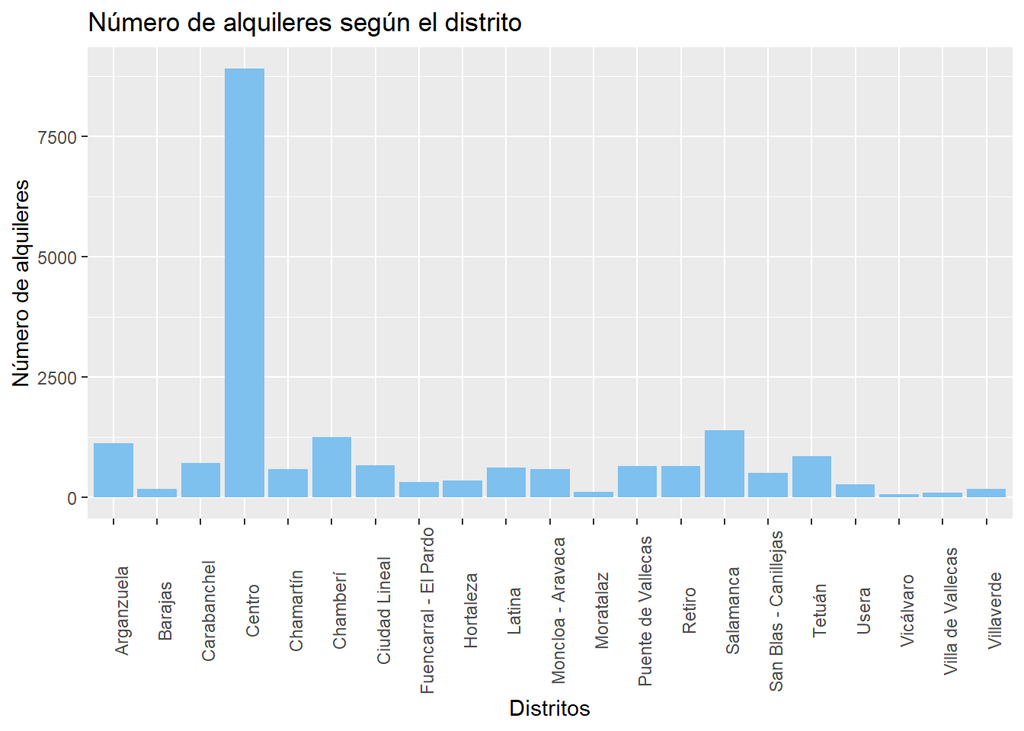

```r
suppressPackageStartupMessages(library(ggplot2))

numerod <- ggplot(datos, aes(neighbourhood_group)) +
  geom_bar(fill = "skyblue2") +
  xlab("Distritos") +
  theme(axis.text.x = element_text(angle = 90))+
  ylab("Número de alquileres") +
  ggtitle("Número de alquileres según el distrito")
numerod
```

El distrito con mayor número de alquileres en Airbnb es el Centro (44%), casi la mitad, seguido, con un número de alquileres mucho menor, por Salamanca, Chamberí y Arganzuela.

Por otro lado, los distritos con menor número de alquileres en Airbnb son Vicálvaro y Villa de Vallecas.

```r
datos %>%
  group_by(neighbourhood_group, neighbourhood) %>%
  summarize(
    numero = n(),
    porcentaje = round(n()/nrow(datos)*100, 2)
  ) %>%
  arrange(desc(numero))
```

```
## # A tibble: 128 x 4
## # Groups:   neighbourhood_group [21]
##    neighbourhood_group neighbourhood   numero porcentaje
##    <fct>               <fct>            <int>      <dbl>
##  1 Centro              Embajadores       2319      11.5
##  2 Centro              Universidad       1906       9.46
##  3 Centro              Palacio           1437       7.13
##  4 Centro              Sol               1310       6.5
##  5 Centro              Justicia          1023       5.08
##  6 Centro              Cortes             918       4.55
##  7 Arganzuela          Palos de Moguer    398       1.97
##  8 Chamberí            Trafalgar          373       1.85
##  9 Salamanca           Goya               325       1.61
## 10 Moncloa - Aravaca   Argüelles          311       1.54
## # ... with 118 more rows
```

```r
datos %>%
  group_by(neighbourhood_group, neighbourhood) %>%
  summarize(
    numero = n(),
    porcentaje = round(n()/nrow(datos)*100, 2)
  ) %>%
  arrange(numero)
```

```
## # A tibble: 128 x 4
## # Groups:   neighbourhood_group [21]
##    neighbourhood_group   neighbourhood  numero porcentaje
##    <fct>                 <fct>           <int>      <dbl>
##  1 Ciudad Lineal         Atalaya             1       0
##  2 Fuencarral - El Pardo El Pardo            3       0.01
##  3 Moratalaz             Horcajo             3       0.01
##  4 Fuencarral - El Pardo Fuentelareina       5       0.02
##  5 Moncloa - Aravaca     El Plantío          5       0.02
##  6 Moncloa - Aravaca     Valdemarín          5       0.02
##  7 Moratalaz             Pavones             6       0.03
##  8 Villa de Vallecas     Santa Eugenia       8       0.04
##  9 Latina                Cuatro Vientos     10       0.05
## 10 Usera                 Orcasitas          13       0.06
## # ... with 118 more rows
```

Si nos vamos al detalle de los barrios, vemos que los barrios con mayor número de alquileres pertenecen al distrito Centro (Embajadores, Universidad, Palacio, Sol, Justicia y Cortes). Mientras que los barrios con menor número de alquileres son Atalaya (Ciudad Lineal), El Pardo (Fuencarral) y Horcajo (Moratalaz).

### 2. Diferencias de precios por barrios y distritos

```r
datos %>%
  group_by(neighbourhood_group, neighbourhood) %>%
  summarize(
    precio_medio = mean(price),
    precio_max = max(price),
    precio_min = min(price),
    variabilidad = sd(price)
  ) %>%
  arrange(desc(precio_medio))
```

```
## # A tibble: 128 x 6
## # Groups:   neighbourhood_group [21]
##    neighbourhood_g~ neighbourhood precio_medio precio_max precio_min
##    <fct>            <fct>                <dbl>      <dbl>      <dbl>
##  1 Arganzuela       Atocha                480.       9999         16
##  2 San Blas - Cani~ Hellín                468.       2000         24
##  3 San Blas - Cani~ Canillejas            466.       3000         11
##  4 Villaverde       San Andrés            448.       8000          9
##  5 San Blas - Cani~ Arcos                 429.       3500         12
##  6 Hortaleza        Palomas               400.       6000         33
##  7 San Blas - Cani~ Rosas                 394.       2700         20
##  8 Latina           Lucero                334.       8000         13
##  9 Hortaleza        Piovera               279.       2229         22
## 10 San Blas - Cani~ Simancas              276.       2600          9
## # ... with 118 more rows, and 1 more variable: variabilidad <dbl>
```

```r
datos %>%
  group_by(neighbourhood_group, neighbourhood) %>%
  summarize(
    precio_medio = mean(price),
    precio_max = max(price),
    precio_min = min(price),
    variabilidad = sd(price)
  ) %>%
  arrange(precio_medio)
```

```
## # A tibble: 128 x 6
## # Groups:   neighbourhood_group [21]
##    neighbourhood_g~ neighbourhood precio_medio precio_max precio_min
##    <fct>            <fct>                <dbl>      <dbl>      <dbl>
##  1 Villaverde       Butarque              31.8         75          9
##  2 Ciudad Lineal    Atalaya               36           36         36
##  3 Latina           Cuatro Vient~         39           75         12
##  4 Barajas          Aeropuerto            40.2         89         18
##  5 Latina           Aluche                40.7        400          9
##  6 Usera            Moscardó              41.1        160         11
##  7 Usera            San Fermín            44          145         12
##  8 Carabanchel      Vista Alegre          46.7        400          9
##  9 Moratalaz        Horcajo               47           55         36
## 10 Moratalaz        Pavones               48.2        146         17
## # ... with 118 more rows, and 1 more variable: variabilidad <dbl>
```

Vemos que los barrios con los precios medios más altos son Atocha (Arganzuela), Hellín y Canillejas (San Blas). Los que tienen la media de precios más baja son Butarque (Villaverde), Atalaya (Ciudad Lineal) y Cuatro Vientos (Latina).

La diferencia entre los precios medios más altos y los más bajos es bastante alta, pudiendo ser de hasta 400€. También observamos que la variabilidad de precios es mayor en los barrios cuyo precio medio es más alto.

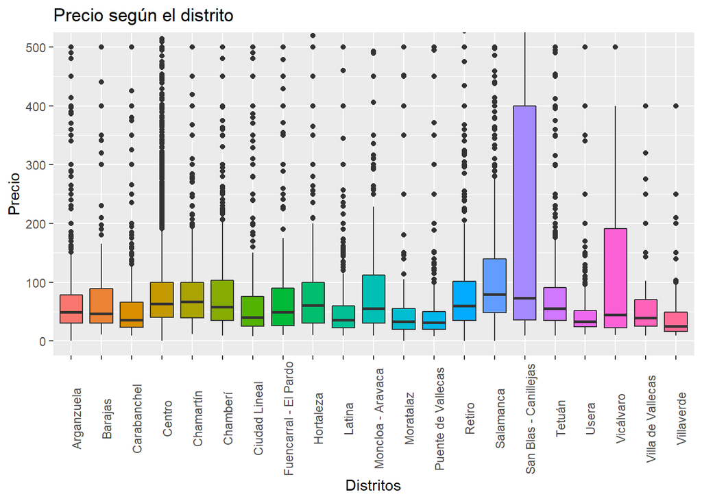

```r
preciod <- ggplot(datos, aes(neighbourhood_group, price)) +
  geom_boxplot(aes(fill = neighbourhood_group)) +
  coord_cartesian(ylim = c(0,500)) +
  xlab("Distritos") +
  theme(axis.text.x = element_text(angle = 90)) +
  ylab("Precio") +
  ggtitle("Precio según el distrito") +
  theme(legend.position="none")
preciod
```

En el gráfico observamos que las medianas de precios son más altas en los distritos de Salamanca y San Blas. Los distritos de San Blas y Vicálvaro destacan por tener una mayor dispersión del precio respecto a los otros distritos.

A pesar de que el precio medio más alto se encuentre en el barrio de Atocha, perteneciente a Arganzuela, al agrupar únicamente por distritos, el precio medio de Arganzuela no destaca por encima del resto.

El gráfico también nos muestra la existencia de una gran cantidad de valores outliers, es decir, que no respresentan la mayoría de la población y podrían influir en la modelización. Hemos cortado la escala de la coordenada $y$ debido a que algunos outliers eran demasiado altos. Para ver a qué pueden deberse estos precios tan altos, vamos a ordenar de mayor a menor precio todos los alojamientos.

```r
consulta1 <- datos %>%
  arrange(desc(price))
head(consulta1)
```

```
##         id                                      name   host_id       host_name
## 1   177500                       Fuencarral studio A    596469  Gabriel Avalos
## 2 13014111                     Velazquez Apartment I    596469  Gabriel Avalos
## 3 13221821       CENTRE OF MADRID. SANTA ANA AND SOL  74180884         Antonio
## 4 13892731                          Diseño en Atocha  29053317 Doris Y Ángeles
## 5 15645521 Wonderful Location: Atocha/Museums/Retiro 100942694           David
## 6 15912862             Duplex Diseño Hortaleza y Sol  29053317 Doris Y Ángeles
##   neighbourhood_group   neighbourhood latitude longitude       room_type price
## 1              Centro     Universidad 40.42762  -3.70323 Entire home/apt  9999
## 2           Salamanca      Castellana 40.43448  -3.68264 Entire home/apt  9999
## 3              Centro          Cortes 40.41406  -3.70294 Entire home/apt  9999
## 4          Arganzuela Palos de Moguer 40.40391  -3.69240 Entire home/apt  9999
## 5          Arganzuela          Atocha 40.40588  -3.68988 Entire home/apt  9999
## 6              Centro        Justicia 40.42371  -3.69795 Entire home/apt  9999
##   minimum_nights number_of_reviews last_review reviews_per_month
## 1              5                24  2019-06-28              0.23
## 2              7                10  2019-03-31              0.20
## 3              2               182  2020-03-13              3.21
## 4              2                54  2020-03-31              0.97
## 5              2               181  2020-03-08              3.45
## 6              2               101  2020-03-01              1.96
##   calculated_host_listings_count availability_365
## 1                             32               42
## 2                             32               42
## 3                              2               41
## 4                              5               42
## 5                              1               42
## 6                              5               41
```

Algunos de los precios más altos parecen debidos a un error en el registro de los datos, otros son alojamientos de lujo y otros, sobre todo en el distrito de San Blas, al fijarnos en el nombre, parecen tener precios tan altos debido a que se jugó una final de la Champions en el estadio de futbol ubicado en dicho distrito.

*Nota: Aquí solo mostramos los 6 primeros registros, pero en los siguientes se podrían comprobar los datos comentados*

```r
suppressPackageStartupMessages(library(data.table))
datosdt <- data.table(datos)
datosdt[,.(precio_medio = mean(price)), by = neighbourhood_group][precio_medio > mean(precio_medio)][order(-precio_medio)]
```

```
##      neighbourhood_group precio_medio
## 1: San Blas - Canillejas     325.0493
## 2:            Villaverde     165.5281
## 3:             Hortaleza     159.9943
## 4:             Salamanca     157.5759
## 5:             Vicálvaro     152.3939
## 6:            Arganzuela     136.8559
## 7:                Latina     132.5568
```

En esta tabla podemos ver un listado de los distritos cuyo precio medio está por encima de la media. Vemos que por ejemplo el distrito de Villaverde, en el gráfico de cajas no parece estar por encima de la media, por lo que probablemente los resultados de esta tabla estén influenciados por los valores outlier comentados anteriormente.

### 3. Número de alquileres por tipo de habitación

```r
datos %>%
  group_by(room_type) %>%
  summarize(
    numero = n(),
    porcentaje = round(n()/nrow(datos)*100, 2)
  ) %>%
  arrange(desc(numero))
```

```
## # A tibble: 4 x 3
##   room_type       numero porcentaje
##   <fct>            <int>      <dbl>
## 1 Entire home/apt  11697      58.0
## 2 Private room      7921      39.3
## 3 Shared room        353       1.75
## 4 Hotel room         185       0.92
```

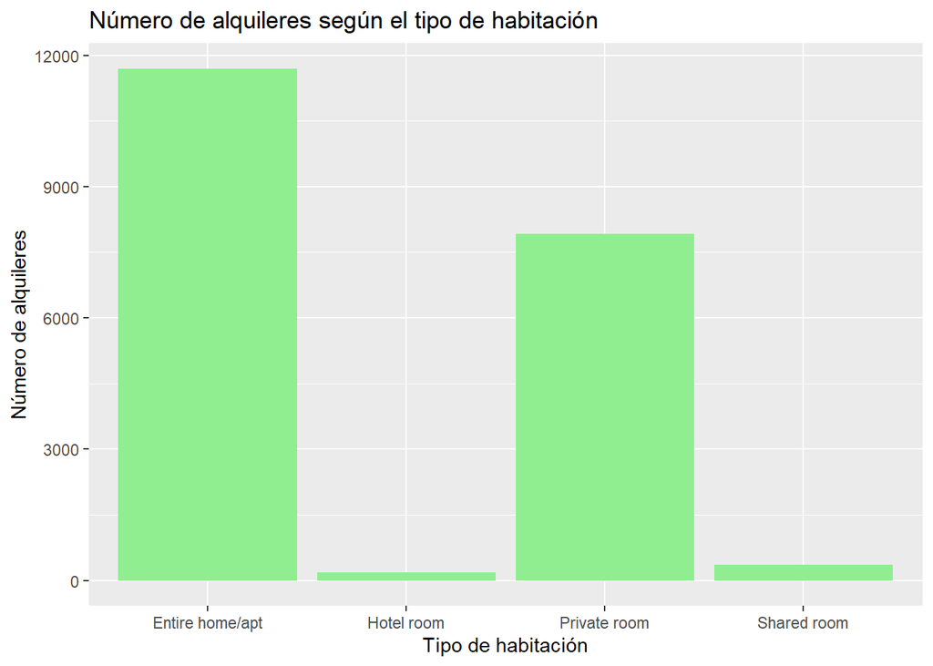

```r
ggplot(datos, aes(room_type)) +
  geom_bar(fill = "palegreen2") +
  xlab("Tipo de habitación") +
  ylab("Número de alquileres") +
  ggtitle("Número de alquileres según el tipo de habitación")
```

Para más de la mitad de los alquileres se alquila el apartamento o casa entera. Un 39% son habitaciones privadas, y un porcentaje muy bajo son habitaciones compartidas o habitaciones de hotel.

### 4. Diferencias de precios según el tipo de habitación

```r
datos %>%
  group_by(room_type) %>%
  summarize(
    precio_medio = mean(price),
    precio_max = max(price),
    precio_min = min(price),
    variabilidad = sd(price)
  ) %>%
  arrange(desc(precio_medio))
```

```
## # A tibble: 4 x 5
##   room_type       precio_medio precio_max precio_min variabilidad
##   <fct>                  <dbl>      <dbl>      <dbl>        <dbl>
## 1 Hotel room             319.        8399          0        1217.
## 2 Entire home/apt        157.        9999          9         546.
## 3 Private room            80.0       9000          8         223.
## 4 Shared room             74.4       3000          9         226.
```

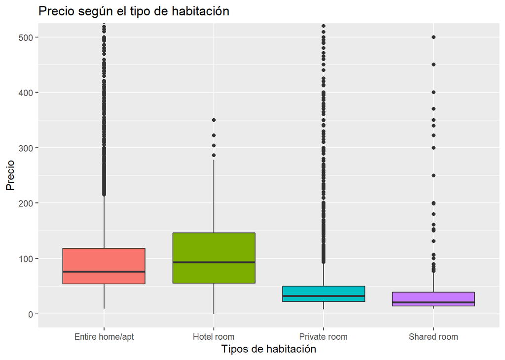

```r
ggplot(datos, aes(room_type, price)) +
  geom_boxplot(aes(fill = room_type)) +
  coord_cartesian(ylim = c(0,500)) +
  xlab("Tipos de habitación") +
  ylab("Precio") +
  ggtitle("Precio según el tipo de habitación") +
  theme(legend.position="none")
```

Las habitaciones de hotel son las que poseen un precio medio mayor y una mayor variabilidad en el precio, seguidas por los apartamentos enteros, mientras que las habitaciones compartidas tiene el precio medio más bajo.

De nuevo observamos que existen una gran cantidad de valores outlier en todos los factores.

### 5. Tipos de habitaciones según los barrios y distritos

```r
datos %>%
  group_by(neighbourhood_group, room_type) %>%
  summarize(numero = n()) %>%
  arrange(neighbourhood_group, desc(numero))
```

```
## # A tibble: 74 x 3
## # Groups:   neighbourhood_group [21]
##    neighbourhood_group room_type       numero
##    <fct>               <fct>            <int>
##  1 Arganzuela          Entire home/apt    593
##  2 Arganzuela          Private room       521
##  3 Arganzuela          Shared room         14
##  4 Arganzuela          Hotel room           3
##  5 Barajas             Private room       117
##  6 Barajas             Entire home/apt     57
##  7 Barajas             Shared room          2
##  8 Carabanchel         Private room       446
##  9 Carabanchel         Entire home/apt    260
## 10 Carabanchel         Shared room          7
## # ... with 64 more rows
```

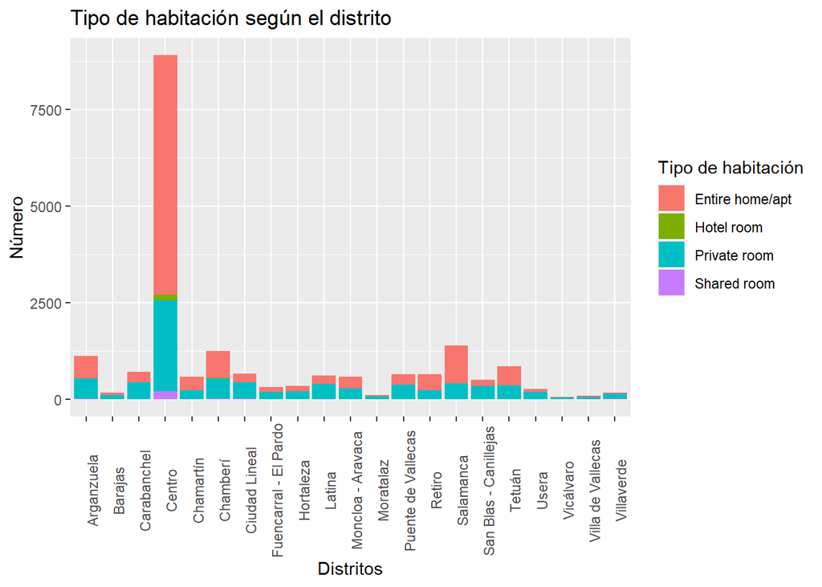

```r
ggplot(datos, aes(neighbourhood_group)) +
  geom_bar(aes(fill = room_type)) +
  xlab("Distritos") +
  theme(axis.text.x = element_text(angle = 90)) +
  ylab("Número") +
  ggtitle("Tipo de habitación según el distrito") +
  scale_fill_discrete(name = "Tipo de habitación")
```

El número de apartamentos enteros alquilados es mayor, ya que en el distrito con mayor número de alquileres (Centro), en su gran mayoría son apartamentos enteros. En algunos distritos, vemos que destacan las habitaciones privadas por encima de los apartamentos enteros, como Barajas, Carabanchel, Ciudad Lineal o la Latina, por ejemplo. Podríamos confirmar que en ninguno de los distritos el número de habitaciones compartidas o habitaciones de hotel es mayor que el de apartamentos enteros o habitaciones privadas.

Dado que el Centro es el distrito con mayor número de alquileres, vamos a analizar si existen diferencias en el tipo de habitación alquiladas según el barrio.

```r
datos %>%
  group_by(neighbourhood, room_type) %>%
  filter(neighbourhood_group == "Centro") %>%
  summarise(numero = n()) %>%
  arrange(neighbourhood, desc(numero))
```

```
## # A tibble: 24 x 3
## # Groups:   neighbourhood [6]
##    neighbourhood room_type       numero
##    <fct>         <fct>            <int>
##  1 Cortes        Entire home/apt    684
##  2 Cortes        Private room       199
##  3 Cortes        Hotel room          27
##  4 Cortes        Shared room          8
##  5 Embajadores   Entire home/apt   1648
##  6 Embajadores   Private room       596
##  7 Embajadores   Shared room         46
##  8 Embajadores   Hotel room          29
##  9 Justicia      Entire home/apt    687
## 10 Justicia      Private room       303
## # ... with 14 more rows
```

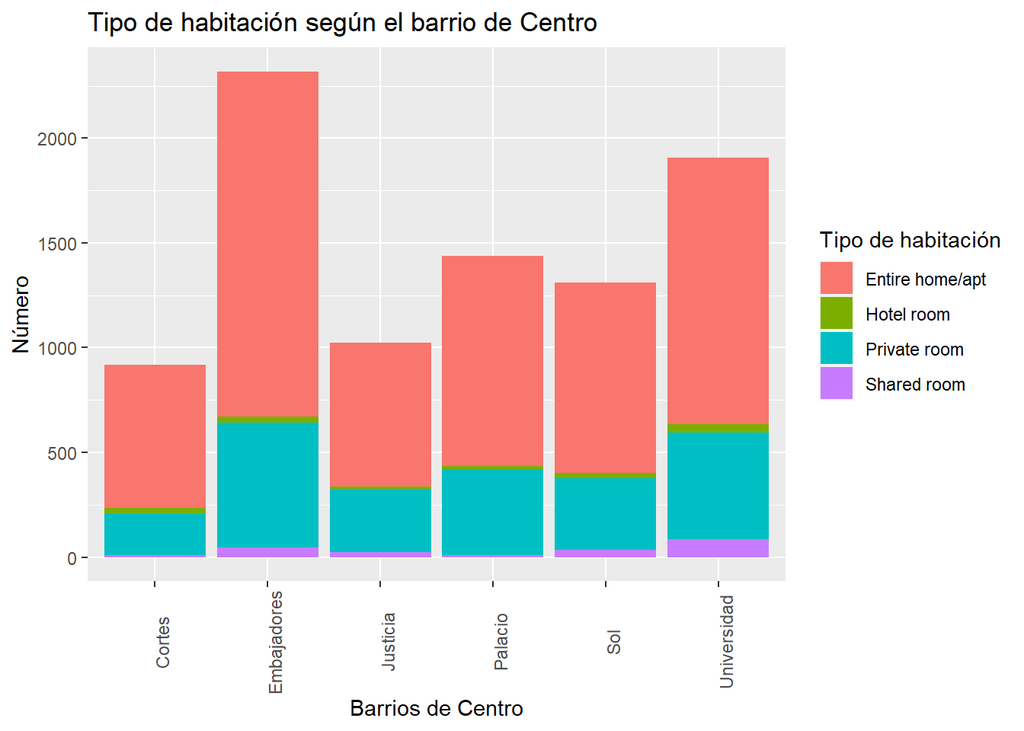

```r
ggplot(data = filter(datos, neighbourhood_group == "Centro"), aes(neighbourhood)) +
  geom_bar(aes(fill = room_type)) +
  xlab("Barrios de Centro") +
  theme(axis.text.x = element_text(angle = 90)) +
  ylab("Número") +
  ggtitle("Tipo de habitación según el barrio de Centro") +
  scale_fill_discrete(name = "Tipo de habitación")
```

A simple vista parece que no existen diferencias significativas y en todos los barrios del Centro siguen predominando los apartamentos enteros y las habitaciones privadas sobre los otros dos. Podría destacarse simplemente, que en el barrio Universidad hay un mayor número de habitaciones compartidas que en el resto, lo cuál tiene sentido al tratarse de un barrio frecuentado por gente joven.

### 6. Número mínimo de noches según el tipo de habitación

```r
datosdt[,.(media_noches_min = mean(minimum_nights),
            mediana_noches_min = median(minimum_nights),
            maximo = max(minimum_nights),
            minimo = min(minimum_nights)), by =room_type][order(-media_noches_min)]
```

```
##          room_type media_noches_min mediana_noches_min maximo minimo
## 1: Entire home/apt         6.893904                  2   1125      1
## 2:      Hotel room         6.848649                  1   1000      1
## 3:    Private room         6.005050                  1   1125      1
## 4:     Shared room         4.209632                  1    365      1
```

El número de noches minimas de media suele ser 6 en cada tipo de habitación, excepto en las compartidas que es 4. Esto nos llama la atención, ya que en general se suele requerir una reserva mínima de 1 o 2 noches en los alojamientos. Al revisar los valores máximos, vemos que hay valores muy altos que están influyendo en la media, mientras que la mediana nos muestra unos valores más lógicos (mínimo de 2 noches en los apartamentos enteros y 1 en el resto).

```r
consulta2 <- datos %>%
  arrange(desc(minimum_nights))
head(consulta2)
```

```
##         id                                          name   host_id   host_name
## 1 18850626 Habitación privada en el centro con wifi y tv 131308210     Fiorela
## 2 32606898                           Your home en Madrid 245111355      Angela
## 3 34993715                              Champions League  38373657     Alberto
## 4 37311541       como en casa y con 2 amigos nuevos fijo 280880414     Jose M.
## 5 23974942   Loft Best neighbourhood in the world! Book! 180323447      Felipe
## 6 30140427                                  Como en casa 226466448 Apartahotel
##   neighbourhood_group neighbourhood latitude longitude       room_type price
## 1              Centro      Justicia 40.42503  -3.70046    Private room    36
## 2         Carabanchel    San Isidro 40.39156  -3.73813    Private room    30
## 3           Hortaleza Pinar del Rey 40.47050  -3.64819 Entire home/apt  1000
## 4              Latina      Cármenes 40.40271  -3.74331    Private room    22
## 5              Centro        Cortes 40.41098  -3.69496 Entire home/apt  1875
## 6           Salamanca    Guindalera 40.43620  -3.67188      Hotel room    89
##   minimum_nights number_of_reviews last_review reviews_per_month
## 1           1125                60  2019-11-09              1.33
## 2           1125                20  2020-01-24              0.84
## 3           1125                 0        <NA>                NA
## 4           1125                 1  2019-09-12              0.06
## 5           1000                46  2020-02-24              1.32
## 6           1000                 0        <NA>                NA
##   calculated_host_listings_count availability_365
## 1                              1               37
## 2                              1                0
## 3                              1               89
## 4                              1              363
## 5                              1              263
## 6                              1              365
```

Al ordenar los alojamientos según el mínimo de noches, vemos que los que exigen un número de noches muy alto suelen ser alquileres de viviendas habituales, por meses o de larga estáncia, no alquileres vacacionales. Otros pueden ser debidos a errores en el registro de los datos, ya que 1.125 noches de estancia mínimas, no parece un valor lógico.

*Nota: Aquí solo mostramos los 6 primeros registros, pero en los siguientes se podrían comprobar los datos comentados*

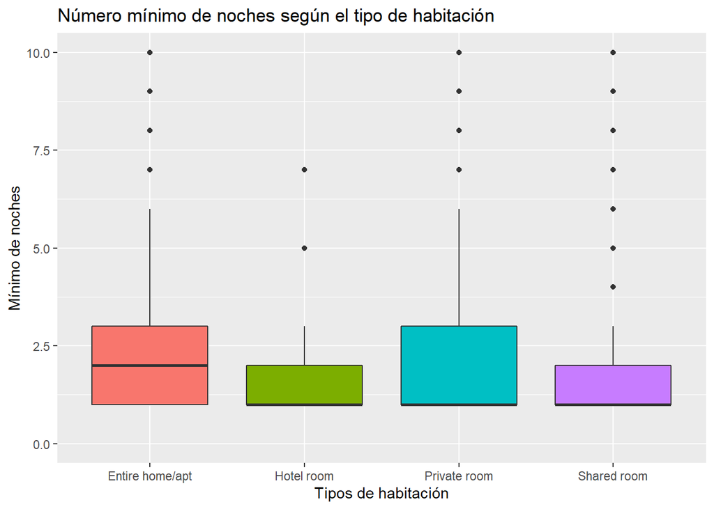

```r
ggplot(datos, aes(room_type, minimum_nights)) +
  geom_boxplot(aes(fill = room_type)) +
  coord_cartesian(ylim = c(0,10)) +
  xlab("Tipos de habitación") +
  ylab("Mínimo de noches") +
  ggtitle("Número mínimo de noches según el tipo de habitación") +
  theme(legend.position="none")
```

En el gráfico se ve que, tal y como comentabamos antes, las medianas están en 2 y 1, siendo mayor para los apartamentos enteros. Observamos la existencia de muchos outliers con valores muy altos, debido a lo comentado anteriormente sobre alquileres no vacacionales. Sería conveniente corregir la influencia de estos valores extremos.

### 7. Número mínimo de noches por barrios y distritos

```r
datos %>%
  group_by(neighbourhood_group, neighbourhood) %>%
  summarize(media_noches_min = mean(minimum_nights),
            mediana_noches_min = median(minimum_nights),
            maximo = max(minimum_nights),
            minimo = min(minimum_nights)) %>%
  arrange(desc(mediana_noches_min))
```

```
## # A tibble: 128 x 6
## # Groups:   neighbourhood_group [21]
##    neighbourhood_g~ neighbourhood media_noches_min mediana_noches_~ maximo
##    <fct>            <fct>                    <dbl>            <dbl>  <dbl>
##  1 Fuencarral - El~ Fuentelareina             8.8                11     11
##  2 Ciudad Lineal    Atalaya                   7                   7      7
##  3 Barajas          Aeropuerto               11.7                 5     30
##  4 Chamartín        El Viso                  12.1                 3    365
##  5 Chamartín        Nueva España              6.49                3     30
##  6 Latina           Cuatro Vient~             9.9                 3     70
##  7 Moncloa - Arava~ Aravaca                  18.5                 3    365
##  8 Moncloa - Arava~ Valdemarín                2.4                 3      3
##  9 Retiro           Estrella                 18.5                 3    300
## 10 Salamanca        Castellana               10.3                 3     89
## # ... with 118 more rows, and 1 more variable: minimo <dbl>
```

Al analizar el número mínimo de noches por distritos y barrios, nos sucede lo mismo que con el tipo de habitación, los valores outlier influyen mucho en las medias haciendo que se obtengan valores demasiado altos. Por tanto, volvemos a tomar como referencia la mediana, que nos muestra que los barrios de Fuentelareina (Fuencarral), Atalaya (Ciudad Lineal) y Barajas (Aeropuerto) es en los que se exige un mayor número mínimo de noches (11, 7 y 5 respectivamente).

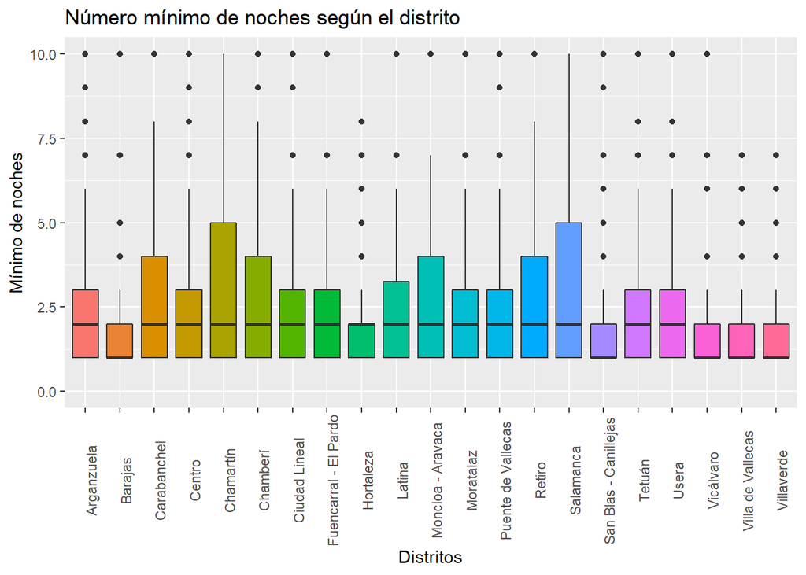

```r
nochesd <- ggplot(datos, aes(neighbourhood_group, minimum_nights)) +
  geom_boxplot(aes(fill = neighbourhood_group)) +
  coord_cartesian(ylim = c(0,10)) +
  xlab("Distritos") +
  theme(axis.text.x = element_text(angle = 90)) +
  ylab("Mínimo de noches") +
  ggtitle("Número mínimo de noches según el distrito") +
  theme(legend.position="none")
nochesd
```

Al eliminar la agrupación por barrios, vemos que la mediana para cada uno de los distritos es siempre de 2 o 1. La dispersión es mayor en los distritos de Chamartín y Salamanca. De nuevo, volvemos a observar una gran cantidad de valores outliers.

### 8. Disponibilidad según el tipo de habitación

```r
datos %>%
  group_by(room_type) %>%
  summarise(disponibilidad_media = mean(availability_365)) %>%
  arrange(desc(disponibilidad_media))
```

```
## # A tibble: 4 x 2
##   room_type       disponibilidad_media
##   <fct>                          <dbl>
## 1 Hotel room                      235.
## 2 Shared room                     185.
## 3 Entire home/apt                 167.
## 4 Private room                    155.
```

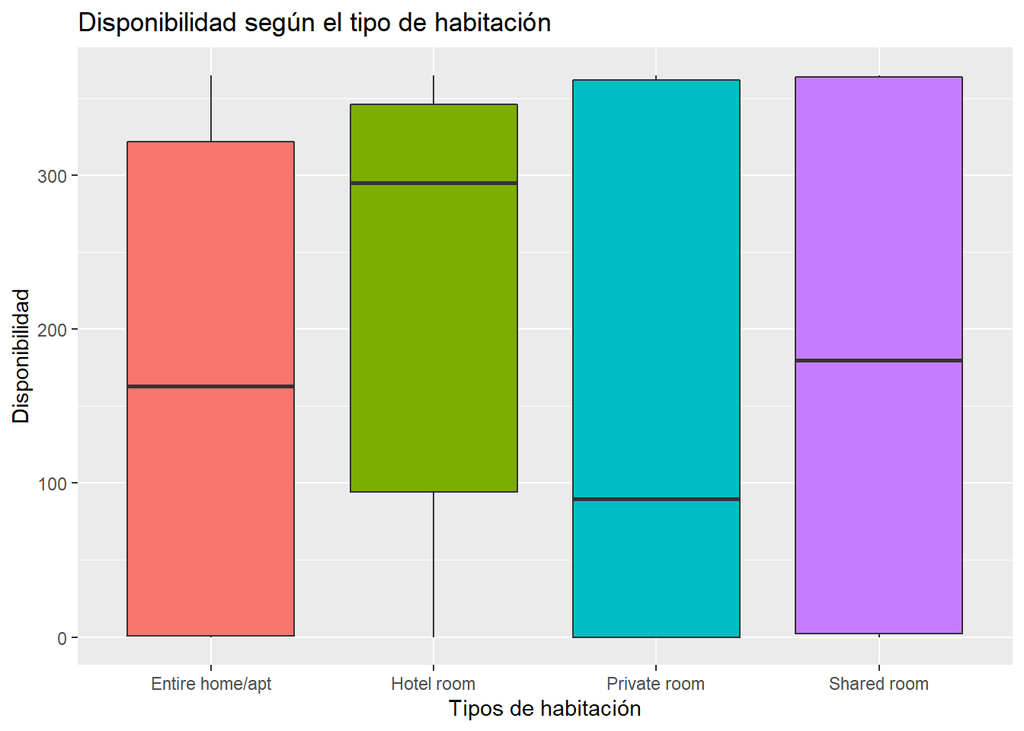

```r
ggplot(datos, aes(room_type, availability_365)) +
  geom_boxplot(aes(fill = room_type)) +
  xlab("Tipos de habitación") +
  ylab("Disponibilidad") +
  ggtitle("Disponibilidad según el tipo de habitación") +
  theme(legend.position="none")
```

Vemos que hay una mayor disponibilidad en las habitaciones de hotel, probablemente relacionado con que su precio medio también es mayor. Por otro lado, las habitaciones privadas tienen menor disponibilidad, las cuales tenían un menor precio medio.

Aunque las habitaciones compartidas también tienen un precio medio bajo, su disponibilidad es mayor. Intuímos que se debe a la menor comodidad que ofrece una habitación compartida en comparación con una habitación privada a un precio similar. El precio medio para las habitaciones privadas era de 80,03€ y para las compartidas 74,43€.

### 9. Disponibilidad por barrios y distritos

```r
datos %>%
  group_by(neighbourhood_group, neighbourhood) %>%
  summarise(disponibilidad_media = mean(availability_365)) %>%
  arrange(desc(disponibilidad_media))
```

```
## # A tibble: 128 x 3
## # Groups:   neighbourhood_group [21]
##    neighbourhood_group   neighbourhood  disponibilidad_media
##    <fct>                 <fct>                         <dbl>
##  1 San Blas - Canillejas Hellín                         239.
##  2 Fuencarral - El Pardo Fuentelareina                  235.
##  3 San Blas - Canillejas Arcos                          227.
##  4 Chamartín             Nueva España                   226.
##  5 Fuencarral - El Pardo La Paz                         225.
##  6 Puente de Vallecas    San Diego                      223.
##  7 San Blas - Canillejas Salvador                       218.
##  8 Carabanchel           Abrantes                       217.
##  9 Ciudad Lineal         Costillares                    215.
## 10 Latina                Cuatro Vientos                 208.
## # ... with 118 more rows
```

```r
datos %>%
  group_by(neighbourhood_group, neighbourhood) %>%
  summarise(disponibilidad_media = mean(availability_365)) %>%
  arrange(disponibilidad_media)
```

```
## # A tibble: 128 x 3
## # Groups:   neighbourhood_group [21]
##    neighbourhood_group   neighbourhood     disponibilidad_media
##    <fct>                 <fct>                            <dbl>
##  1 Moratalaz             Pavones                           59.5
##  2 Fuencarral - El Pardo El Pardo                          89.7
##  3 Moratalaz             Media Legua                       97.0
##  4 Ciudad Lineal         San Juan Bautista                118.
##  5 Fuencarral - El Pardo El Goloso                        119.
##  6 Villaverde            Butarque                         123.
##  7 Usera                 Orcasitas                        126.
##  8 Arganzuela            Chopera                          129.
##  9 Arganzuela            Delicias                         129.
## 10 Arganzuela            Imperial                         129.
## # ... with 118 more rows
```

Los barrios con mayor número de días disponibles de media son Hellín (San Blas), Fuentelareina (Fuencarral) y Arcos (San Blas). Recordamos que el distrito de San Blas era uno de los que tenía los precios medios más altos, y el barrio de Fuentelareina era el que mayor número mínimo de noches exigía. El distrito de San Blas probablemente tenga mayor disponibilidad a lo largo del año, ya que muchos alojamientos se alquilarían de forma puntual para la final de la Champions.

Observamos también que los barrios con menor disponibilidad son Pavones (Moratalaz), El Pardo (Fuencarral) y Media Legua (Moratalaz). Moratalaz era uno de los distritos con menor número de alquileres ofertados y a su vez de los de menor precio medio, lo cual explicaría su baja disponibilidad.

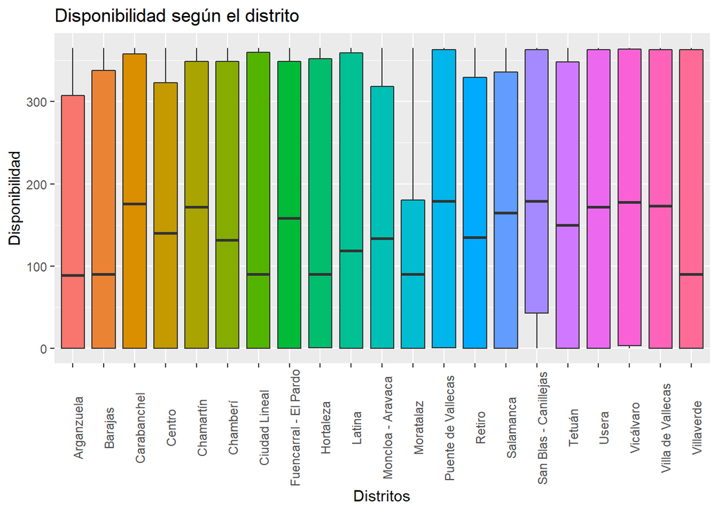

```r
dispod <- ggplot(datos, aes(neighbourhood_group, availability_365)) +
  geom_boxplot(aes(fill = neighbourhood_group)) +
  xlab("Distritos") +
  theme(axis.text.x = element_text(angle = 90)) +
  ylab("Disponibilidad") +
  ggtitle("Disponibilidad según el distrito") +
  theme(legend.position="none")
dispod
```

En la mayor parte de los distritos, la disponibilidad media es muy similar, destacando por ser menor en los distritos de Arganzuela, Barajas, Ciudad Lineal, Hortaleza, Moratalaz y Villaverde.

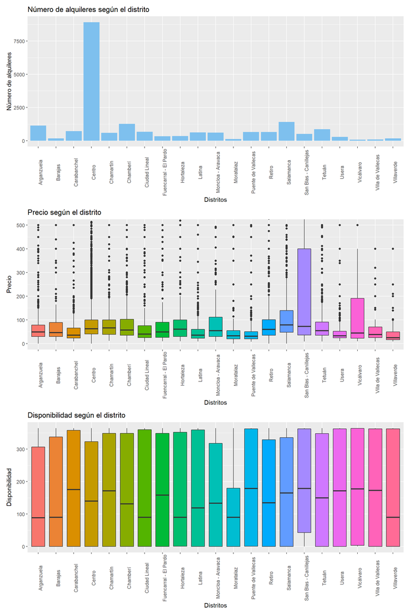

```r
library(patchwork)
(numerod) /
  (preciod)/
  (dispod)
```

Viendo los 3 gráficos en conjunto, podemos ver con mayor claridad el caso de Moratalaz comentado anteriormente. Hay otros distritos con poca oferta de alquileres y bajos precios, pero que tienen mayor disponibilidad como Puente de Vallecas o Usera, probablemente debido al menor interés turístico de las zonas.

### 10. Disponibilidad según el número mínimo de noches

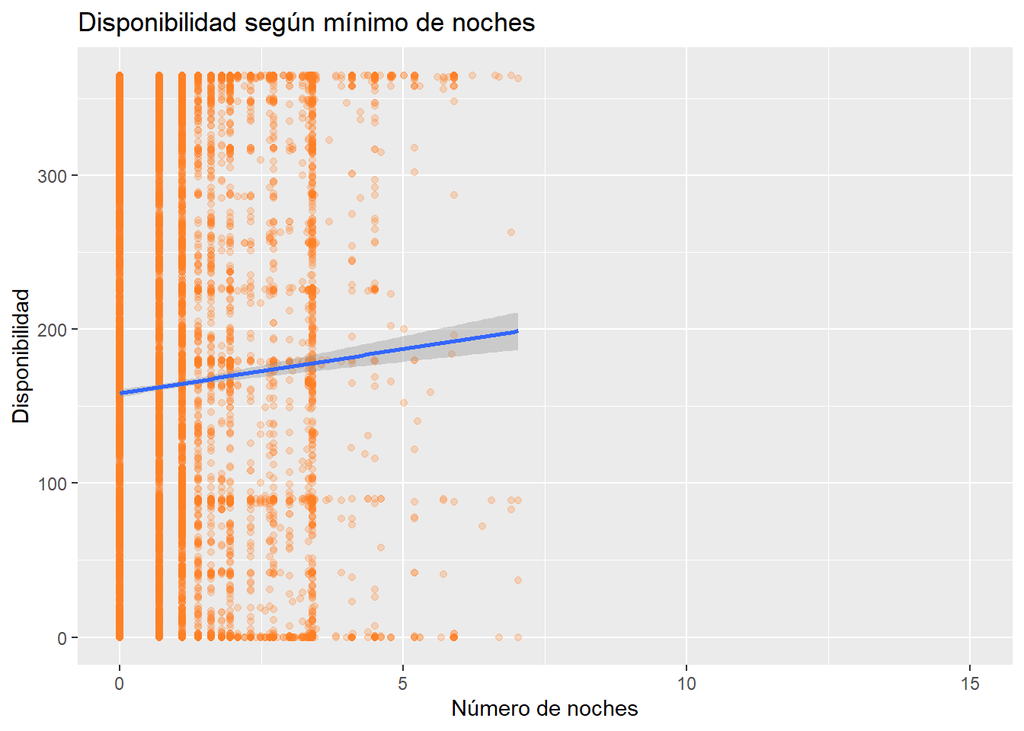

```r
ggplot(datos, aes(log(minimum_nights), availability_365)) +
  geom_point(colour = "chocolate1", alpha = 0.25) +
  coord_cartesian(xlim = c(0,15)) +
  stat_smooth(method = "auto", formula = y ~ x, size = 1) +
  scale_x_continuous(lim = c(0, quantile(datos$minimum_nights, 0.99)) )  +
  scale_y_continuous(lim = c(0, quantile(datos$availability_365, 0.99)) ) +
  xlab("Número de noches") +
  ylab("Disponibilidad") +
  ggtitle("Disponibilidad según mínimo de noches")
```

En este gráfico hemos aplicado una transformación logarítmica sobre el número de noches mínimo, para reducir la influencia de los valores outliers, y un corte en la coordenada $x$ para poder ver el gráfico con más claridad.

Viendo el resultado, parece que podría existir cierta relación entre la disponibilidad y el número de noches mínimo, siendo mayor la disponibilidad a lo largo del año en los alojamientos que exigen un número mínimo de noches mayor, es decir, que tienen un menor número de reservas.

### 11. Precio según varios factores

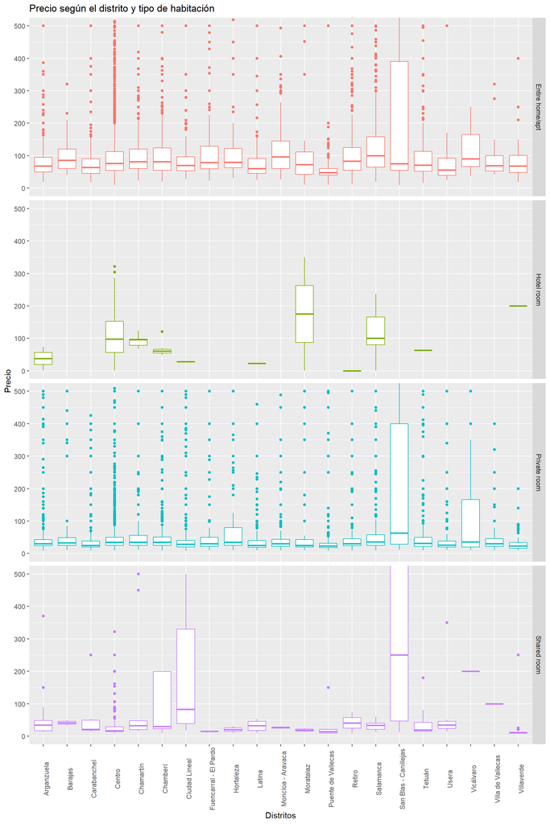

```r
ggplot(datos, aes(neighbourhood_group, price)) +
  geom_boxplot(aes(color = room_type)) +
  coord_cartesian(ylim = c(0,500)) +
  facet_grid(room_type~.) +
  xlab("Distritos") +
  theme(axis.text.x = element_text(angle = 90)) +
  ylab("Precio") +
  ggtitle("Precio según el distrito y tipo de habitación") +
  theme(legend.position="none")
```

Otros dos casos son Moratalaz y Villaverde, cuyo precio medio de las habitaciones de hotel es mayor comparados con el resto de distritos, mientras que para los otros tipos de habitación es similar.

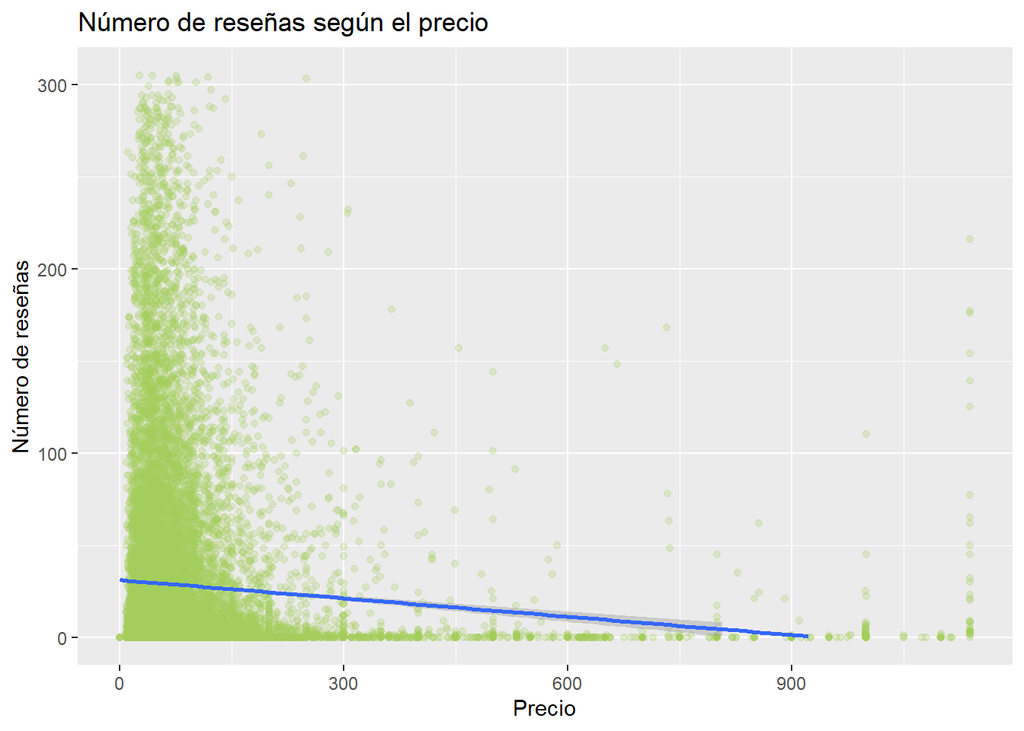

```r
ggplot(datos, aes(price, number_of_reviews)) +
  geom_point(colour = "darkolivegreen3", alpha = 0.25) +
  stat_smooth(method = "auto", formula = y ~ x, size = 1) +
  scale_x_continuous(lim = c(0, quantile(datos$price, 0.99)) )  +
  scale_y_continuous(lim = c(0, quantile(datos$number_of_reviews, 0.99)) ) +
  xlab("Precio") +
  ylab("Número de reseñas") +
  ggtitle("Número de reseñas según el precio")
```

Al comparar el número de reseñas con los precios, parece que a medida que aumenta el precio, disminuye el número de reseñas. También puede verse influenciado por el menor número de alquileres con precios altos.

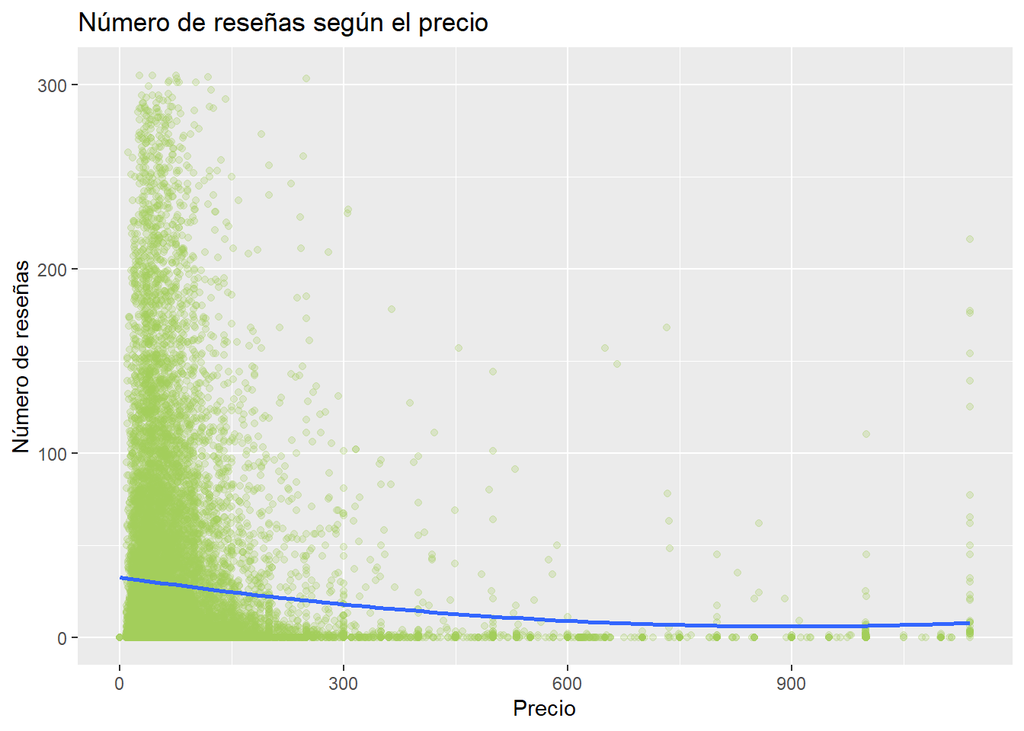

```r
ggplot(datos, aes(price, number_of_reviews)) +
  geom_point(colour = "darkolivegreen3", alpha = 0.25) +
  geom_smooth(method = "lm", formula = y ~ poly(x, 2), se = FALSE) +
  scale_x_continuous(lim = c(0, quantile(datos$price, 0.99)) )  +
  scale_y_continuous(lim = c(0, quantile(datos$number_of_reviews, 0.99)) ) +
  xlab("Precio") +
  ylab("Número de reseñas") +
  ggtitle("Número de reseñas según el precio")
```

Al aplicar una función polinómica de segundo grado, vemos que esta se ajusta un poco mejor a la distribución de los residuos. Si aplicasemos una de tercer grado, se vería influenciada por los valores outlier del precio.

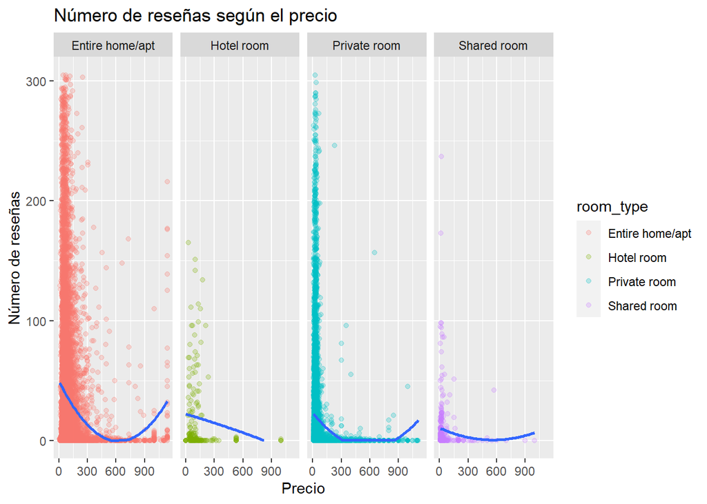

```r
ggplot(datos, aes(price, number_of_reviews)) +
  geom_point(aes(color = room_type), alpha = 0.25) +
  facet_grid(.~room_type) +
  geom_smooth(method = "lm", formula = y ~ poly(x, 2), se = FALSE) +
  scale_x_continuous(lim = c(0, quantile(datos$price, 0.99)) )  +
  scale_y_continuous(lim = c(0, quantile(datos$number_of_reviews, 0.99)) ) +
  xlab("Precio") +
  ylab("Número de reseñas") +
  ggtitle("Número de reseñas según el precio")
```

Al dividir por tipo de habitación, vemos cierta diferencia en las habitaciones de hotel, en las que se aprecia una relación más lineal. Para el resto de habitaciones vemos que tiende a aumentar de nuevo el número de reseñas en los precios más altos, apróximadamente a partir de los 600€. La curvatura es más pronunciada en los apartamenteos enteros, probablemente debido al mayor número de alquileres de este tipo de habitaciones.